# Identifying Correct Dumbell Lifts

Liesl Schwab

Tuesday, July 14, 2015

## Introduction

Our goal for this project is to examine data collected from a small subset of six men aged 20-28 and try to determine how they were lifting the dumbbell given the measurements taken during the lifting. This type of activity identification could be very useful in a variety of applications; for example, providing feedback to athletes.

## Processing Data

#### Load required libraries:

```r
library( caret )
library( rpart )
library( rattle )
```

```r
library( rpart.plot )
library( AppliedPredictiveModeling )
library( randomForest )
set.seed( 125 ) ## Set the seed for reproduction
```

#### Load the required datasets:

Let NA’s, DIV/0!, and blank entries all be considered NA values. Let us also clean the data to eliminate variables that may not be of as much use during prediction of the type of activity. First, we remove the first 7 columns as they are not useful predictors, then we remove columns that contain a majority of NA values (over 60%) as they are also not useful predictors.

```r
bigtrain <- read.csv("pml-training.csv", na.strings=c("NA","#DIV/0!",""))
test <- read.csv("pml-testing.csv", na.strings=c("NA","#DIV/0!",""))

## Remove first 7 cols
bigtrain <- bigtrain[,8:length(colnames(bigtrain))]

## Remove close to zero variance cols and cols with large number of NAs
drop <- c()
for( col in 1:(ncol( bigtrain ) - 1) ){
      colname <- colnames(bigtrain)[col]
      if( sum( is.na( bigtrain[,col])) / nrow( bigtrain ) >= 0.6  ) drop <- c( drop, colnames(bigtrain)[col])
}

bigtrain <- bigtrain[,!colnames(bigtrain) %in% drop]
```

Our remaining predictors are then:

```r
colnames( bigtrain )
```

```
##  [1] "roll_belt"            "pitch_belt"           "yaw_belt"
##  [4] "total_accel_belt"     "gyros_belt_x"         "gyros_belt_y"
##  [7] "gyros_belt_z"         "accel_belt_x"         "accel_belt_y"
## [10] "accel_belt_z"         "magnet_belt_x"        "magnet_belt_y"
## [13] "magnet_belt_z"        "roll_arm"             "pitch_arm"
## [16] "yaw_arm"              "total_accel_arm"      "gyros_arm_x"
## [19] "gyros_arm_y"          "gyros_arm_z"          "accel_arm_x"
## [22] "accel_arm_y"          "accel_arm_z"          "magnet_arm_x"
## [25] "magnet_arm_y"         "magnet_arm_z"         "roll_dumbbell"
## [28] "pitch_dumbbell"       "yaw_dumbbell"         "total_accel_dumbbell"
## [31] "gyros_dumbbell_x"     "gyros_dumbbell_y"     "gyros_dumbbell_z"
## [34] "accel_dumbbell_x"     "accel_dumbbell_y"     "accel_dumbbell_z"
## [37] "magnet_dumbbell_x"    "magnet_dumbbell_y"    "magnet_dumbbell_z"
## [40] "roll_forearm"         "pitch_forearm"        "yaw_forearm"
## [43] "total_accel_forearm"  "gyros_forearm_x"      "gyros_forearm_y"
## [46] "gyros_forearm_z"      "accel_forearm_x"      "accel_forearm_y"
## [49] "accel_forearm_z"      "magnet_forearm_x"     "magnet_forearm_y"
## [52] "magnet_forearm_z"     "classe"
```

Then, let us split the given training data into a training set and a test set:

```r
# Split the training set into a training and test set
inTrain <- createDataPartition( y = bigtrain$classe, p = 0.6, list = FALSE )
newtrain <- bigtrain[ inTrain, ]
newtest <- bigtrain[ -inTrain, ]
```

## Predictions

### Classification Tree

First, we will run a prediction using a decision/classification tree:

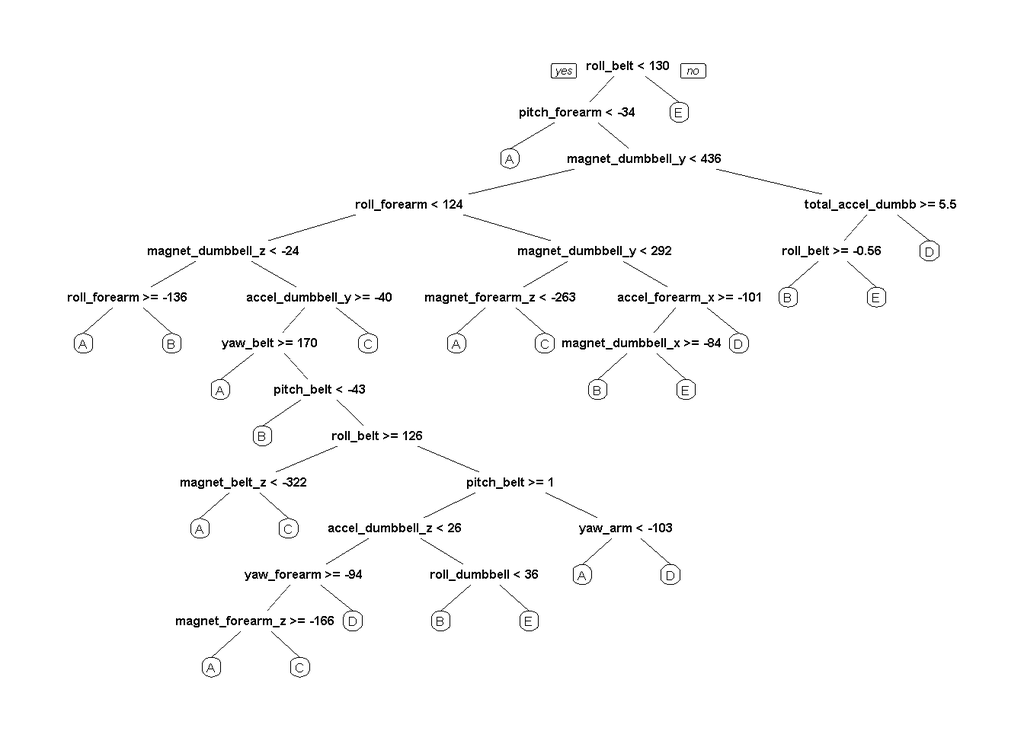

```r
fit1 <- rpart( classe ~ ., data = newtrain, method = "class" )
pred1 <- predict( fit1, newdata = newtest, type = "class" )

## View Plot
rpart.plot(fit1)
```

Then we will examine the confusion matrix:

```r
cm1 <- confusionMatrix( pred1, newtest$classe )
cm1
```

```
## Confusion Matrix and Statistics
##
##           Reference
## Prediction    A    B    C    D    E
##          A 2041  240   38   82   26
##          B   72  831   78   95  119
##          C   65  206 1083  194  189
##          D   25  100   75  797   59
##          E   29  141   94  118 1049
##
## Overall Statistics
##
##                Accuracy : 0.7394
##                  95% CI : (0.7295, 0.749)
##     No Information Rate : 0.2845
##     P-Value [Acc > NIR] : < 2.2e-16
##
##                   Kappa : 0.6694
##  Mcnemar's Test P-Value : < 2.2e-16
##
## Statistics by Class:
##
##                      Class: A Class: B Class: C Class: D Class: E
## Sensitivity            0.9144   0.5474   0.7917   0.6198   0.7275
## Specificity            0.9312   0.9425   0.8990   0.9605   0.9403
## Pos Pred Value         0.8410   0.6954   0.6235   0.7547   0.7331
## Neg Pred Value         0.9648   0.8967   0.9533   0.9280   0.9387
## Prevalence             0.2845   0.1935   0.1744   0.1639   0.1838
## Detection Rate         0.2601   0.1059   0.1380   0.1016   0.1337
## Detection Prevalence   0.3093   0.1523   0.2214   0.1346   0.1824
## Balanced Accuracy      0.9228   0.7450   0.8454   0.7901   0.8339
```

The accuracy is good, but perhaps a different method could provide better results.

### Random Forest

Next, we will run a prediction using a random forest:

```r
fit2 <- randomForest( classe ~ ., data = newtrain )
pred2 <- predict( fit2, newdata = newtest, type = "class" )
```

Then we will examine the confusion matrix:

```r
cm2 <- confusionMatrix( pred2, newtest$classe )
cm2
```

```
## Confusion Matrix and Statistics
##
##           Reference
## Prediction    A    B    C    D    E
##          A 2232   16    0    0    0
##          B    0 1493   14    0    0
##          C    0    9 1354   39    1
##          D    0    0    0 1247    2
##          E    0    0    0    0 1439
##
## Overall Statistics
##
##                Accuracy : 0.9897
##                  95% CI : (0.9872, 0.9918)
##     No Information Rate : 0.2845
##     P-Value [Acc > NIR] : < 2.2e-16
##
##                   Kappa : 0.9869
##  Mcnemar's Test P-Value : NA
##
## Statistics by Class:
##
##                      Class: A Class: B Class: C Class: D Class: E
## Sensitivity            1.0000   0.9835   0.9898   0.9697   0.9979
## Specificity            0.9971   0.9978   0.9924   0.9997   1.0000
## Pos Pred Value         0.9929   0.9907   0.9651   0.9984   1.0000
## Neg Pred Value         1.0000   0.9961   0.9978   0.9941   0.9995
## Prevalence             0.2845   0.1935   0.1744   0.1639   0.1838
## Detection Rate         0.2845   0.1903   0.1726   0.1589   0.1834
## Detection Prevalence   0.2865   0.1921   0.1788   0.1592   0.1834
## Balanced Accuracy      0.9986   0.9907   0.9911   0.9847   0.9990
```

From this confusion matrix we can see that the random forest analysis give a much better accuracy than the classification tree we generated earlier.

### Out of Sample Error

We will quickly examine the out of sample error for the two methods that we applied. The out of sample error is 1 - accuracy, so for the classification tree we have:

```r
1 - unlist(cm1$overall['Accuracy'])
```

```
##  Accuracy
## 0.2606424
```

and for the random forest method we have:

```r
1 - unlist(cm2$overall['Accuracy'])
```

```
##   Accuracy
## 0.01032373
```

## Apply Model Fits to the Test Sample

The last step in testing out our models is to apply them to the test set of 20 samples. First, for the classification tree we have:

```r
pred3 <- predict( fit1, newdata = test, type = "class" )
print( pred3 )
```

```
##  1  2  3  4  5  6  7  8  9 10 11 12 13 14 15 16 17 18 19 20
##  C  A  E  A  A  C  D  A  A  A  C  E  C  A  E  E  A  B  B  B
## Levels: A B C D E
```

And for the random forest we have:

```r
pred4 <- predict( fit2, newdata = test, type = "class" )
print( pred4 )
```

```
##  1  2  3  4  5  6  7  8  9 10 11 12 13 14 15 16 17 18 19 20
##  B  A  B  A  A  E  D  B  A  A  B  C  B  A  E  E  A  B  B  B
## Levels: A B C D E
```